# act_report

## act_report

In this report we will go through the insights and the visualization we have done. After gathering, assesing and cleaning the data we finally merged and done some observations.  
Based on the cleaned data of the WeRateDogs data we have analyized the following insights and visulized some of them.

### 1. Analyzing for the most popular dog stage

Using the cleaned data we analyzed which dog's life stage is more popular or more common than others. we have counted each stages and found this data.

```
 pupper      185
 doggo        83
 puppo        28
 floofer       9
```

As we can see the analysis the most popular and most common dog life stage is Pupper with count of 185

let's see the visualization for this analysis we have created

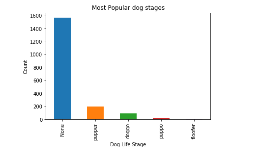

### 2. Analyzing for the most Favourite dog stages

Our second question raised from the data is which dog life stages are more favourite. Using the given data we can get the mean of favourite_count for each dog stage and from the data final mean count for each dogs stage is as follow:

```
    puppo      21550.260870
    doggo      17633.096386
    floofer    11064.444444
    pupper      7935.529730
```

From the above insights we can see that most favourited dog life stage is puppo followed by doggo. We have used the mean of the favourite count or the like count on the twitter.

[figure not shown]

### 3. Analyzing for most retweeted dog stages

Our last observation was which dog's life stages are retweeted most than others. From the data we can get the retweet_count mean for each dog stages and we will get the fillowing data:

```
    puppo      6576.695652
    doggo      6396.373494
    floofer    4155.888889
    pupper     2702.643243
```

From the above insights we can observe that the most retweeted dog stages are puppo which have most retweet count than others.

- As a conculison using the WeRateDogs data after cleaning and merging all the gathered data we can analyze more than this raised Analyitics questions. Even in this small insight we have seen which dog stage is more popular, which dog stage is favourite and which one is more retweeted from the given data